# Explorative Datenanalyse

### Für fünf Kraftwerke

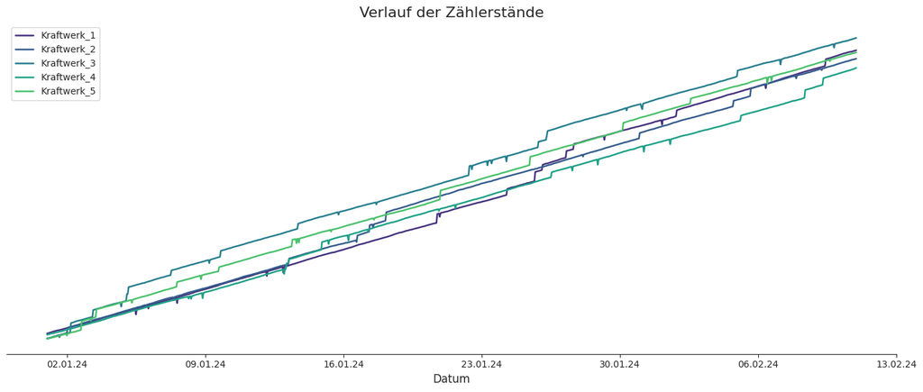

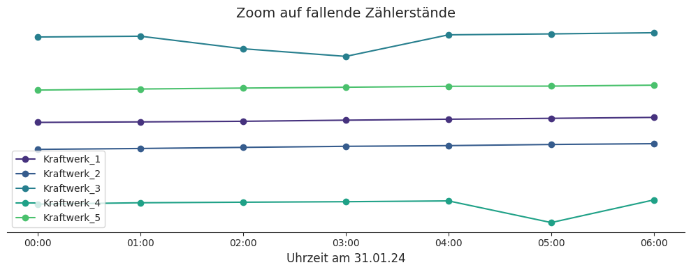

## Rückläufige Zählerstände

### Beobachtung

- Einzelne Zählerstände sinken plötzlich – einmal über zwei aufeinanderfolgende Stunden
- 55 von 5000 Messungen, **entspricht ~1%**

### Mögliche Ursachen

- Übertragungsfehler: die aktuellsten Zählerstände aus dem Cache werden zuerst gesendet
  - die Messwerte kommen in falscher Reihenfolge an, aus [0, 1, 10, 11] wird [0, 10, 1, 11]
  - doch in diesen Daten kündigt kein positiver Sprung den negativer Sprung an
- **Importfehler**: nachträglich eingefügte Werte überschreiben korrekte Messwerte

### Konsequenz für Analyse

- Rückläufige Zählerstände sind physikalisch nicht plausibel
- Verfälschen abgeleitete Kenngrößen wie Produktionsleistung

→ Datenpunkte mit fallendem Zählerstand werden **konsequent entfernt**

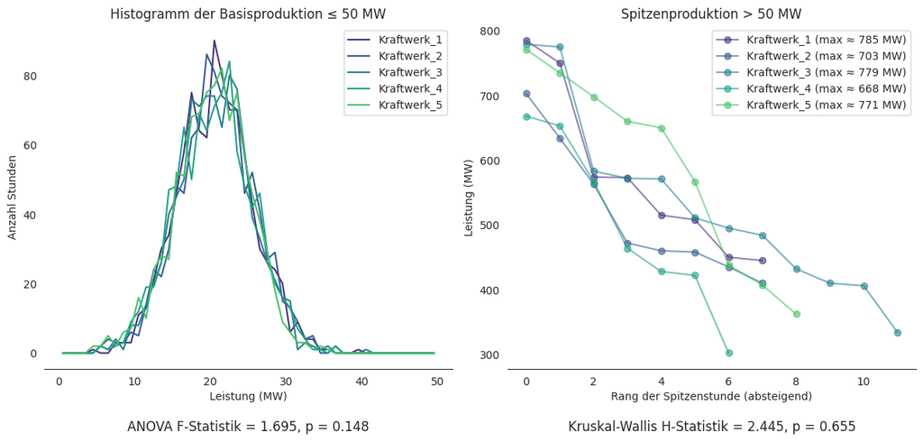

## Hypothese: Gleicher Kraftwerkstyp

Statistische Tests zeigen keine signifikanten Unterschiede zwischen den Kraftwerken.

Es ist **plausibel**, dass es sich bei den fünf Kraftwerken um **denselben Kraftwerkstyp** handelt.

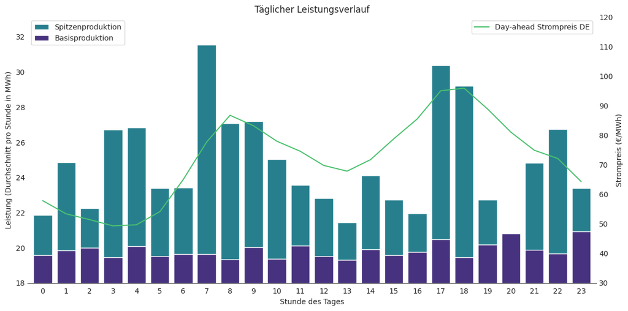

## Leistungsverlauf über den Tag hinweg

1. Konstante Basisproduktion
   - Geringe, stabile Werte deuten auf **gleichmäßige Grundlastversorgung** hin.
2. Zwei Leistungsspitzen
   - Höhere Messwerte treten bevorzugt morgens (7–9 Uhr) und abends (17–18 Uhr) auf.
   - Das Muster passt zu typischen **Nachfrage-Hochlasten**.  
     → Spricht eher für reale Verbrauchsspitzen als für Mess- oder Importfehler  
     (aber nicht eindeutig).

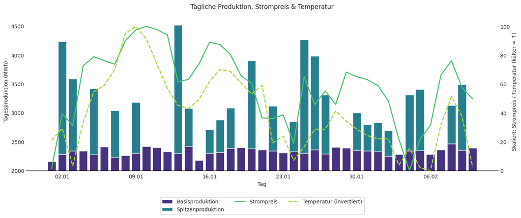

## Fazit: Fahrweise der Anlage

- Keine signifikante Korrelation mit Strompreisen oder Außentemperatur
- Wahrscheinliche Betriebsweise:
  1. **Wärmegeführtes BHKW**
     - mit **Wärmespeicher** oder
     - festen **Fernwärmelast-Verträgen**
  2. **Regelenergiegeführte Anlage**
     - Aktivierung nach Netzbedarf, nicht Marktpreis
- Keine Hinweise auf Peak-Load-Anlage mit Spotmarktoptimierung

## Methodik & Beobachtungen

Tools:

- **Python** (pandas, scipy, matplotlib, seaborn)
- **Jupyter** Notebook zur reproduzierbaren Analyse
- **API**‑Zugriffe für Strompreis- und Wetterdaten

Methodik:

- **Anomalieerkennung** rückläufiger Zählerstände
- Histogramme & Load-Duration-Curves
- **Zeitliche Profile** (Stundenverlauf, Tagesverlauf)
- **Statistische Tests** (ANOVA, Kruskal-Wallis)

Muster:

- **Basislast** der Kraftwerke bei ca. 20 MW
- Wiederkehrende **Spitzen** zwischen 7–9 Uhr & 17–18 Uhr
- **Keine klare Kopplung** an Strompreis oder Außentemperatur
- Potenzielle Probleme: **Rücksprünge in Zählerständen** in ca. 1 % der Datenpunkte

## Dashboard

Tools:

- **BigQuery**: Daten in der Cloud
- **dbt**: Pipelines für die Analyse
- **Looker**: Dashboard

Elemente:

- **Control**: Auswahl des Kraftwerks
- **KPIs**: Grundlast, Spitzenlast, Quote an Spitzenwerten und rückläufigen Zählerständen
- Liste: zum nachschlagen der Spitzenleistungen und Rückläufer
- Diagramm: Leistung am letzten Tag
- **Prognose**: Durchschnittswert dieser Stunde des Tages (SARIMA erkennt keinen Trend)

[Link zum Dashboard](https://lookerstudio.google.com/reporting/44af68b5-399e-4ee3-a1c0-c885fd8d14df)